# Capstone Quiz I

```r
library(ggplot2)
library(dplyr)
library(statsr)
library(devtools)
```

Complete all **Exercises**, and submit answers to **Questions** on the Coursera platform.

This initial quiz will concern exploratory data analysis (EDA) of the Ames Housing dataset. EDA is essential when working with any source of data and helps inform modeling.

First, let us load the data:

```r
load("ames_train.Rdata")
# View(ames_train)
```

1. Which of the following are the three variables with the highest number of missing observations?
   1. `Misc.Feature`, `Fence`, `Pool.QC`
   2. `Misc.Feature`, `Alley`, `Pool.QC`

```r
# type your code for Question 1 here, and Knit
missing_val <- ames_train %>%
  summarise_all(funs(sum(is.na(.))))
# sort and show top 10
head(sort(unlist(missing_val[1,]), decreasing = TRUE), 10)
```

```
##       Pool.QC  Misc.Feature         Alley         Fence  Fireplace.Qu
##           997           971           933           798           491
##  Lot.Frontage Garage.Yr.Blt   Garage.Qual   Garage.Cond   Garage.Type
##           167            48            47            47            46
```

2. How many categorical variables are coded in R as having type `int`? Change them to factors when conducting your analysis.
   1. 0
   2. 1
   3. 2 <-
   4. 3

```r
# type your code for Question 2 here, and Knit
str(ames_train)
```

```
## Classes 'tbl_df', 'tbl' and 'data.frame':    1000 obs. of  81 variables:
##  $ PID            : int  909176150 905476230 911128020 535377150 534177230 908128060 902135020 528228540 923426010 908186050 ...
##  $ area           : int  856 1049 1001 1039 1665 1922 936 1246 889 1072 ...
##  $ price          : int  126000 139500 124900 114000 227000 198500 93000 187687 137500 140000 ...
##  $ MS.SubClass    : int  30 120 30 70 60 85 20 20 20 180 ...
##  $ MS.Zoning      : Factor w/ 7 levels "A (agr)","C (all)",..: 6 6 2 6 6 6 7 6 6 7 ...
##  $ Lot.Frontage   : int  NA 42 60 80 70 64 60 53 74 35 ...
##  $ Lot.Area       : int  7890 4235 6060 8146 8400 7301 6000 3710 12395 3675 ...
##  $ Street         : Factor w/ 2 levels "Grvl","Pave": 2 2 2 2 2 2 2 2 2 2 ...
##  $ Alley          : Factor w/ 2 levels "Grvl","Pave": NA NA NA NA NA NA 2 NA NA NA ...
##  $ Lot.Shape      : Factor w/ 4 levels "IR1","IR2","IR3",..: 4 4 4 4 4 4 4 4 4 4 ...
##  $ Land.Contour   : Factor w/ 4 levels "Bnk","HLS","Low",..: 4 4 4 4 4 4 1 4 4 4 ...
##  $ Utilities      : Factor w/ 3 levels "AllPub","NoSeWa",..: 1 1 1 1 1 1 1 1 1 1 ...
##  $ Lot.Config     : Factor w/ 5 levels "Corner","CulDSac",..: 1 5 5 1 5 1 5 5 1 5 ...
##  $ Land.Slope     : Factor w/ 3 levels "Gtl","Mod","Sev": 1 1 1 1 1 1 2 1 1 1 ...
```

[output cut: 67 more lines]

```r
summary(ames_train)
```

```
##       PID                 area          price         MS.SubClass
##  Min.   :5.263e+08   Min.   : 334   Min.   : 12789   Min.   : 20.00
##  1st Qu.:5.285e+08   1st Qu.:1092   1st Qu.:129763   1st Qu.: 20.00
##  Median :5.354e+08   Median :1411   Median :159467   Median : 50.00
##  Mean   :7.059e+08   Mean   :1477   Mean   :181190   Mean   : 57.15
##  3rd Qu.:9.071e+08   3rd Qu.:1743   3rd Qu.:213000   3rd Qu.: 70.00
##  Max.   :1.007e+09   Max.   :4676   Max.   :615000   Max.   :190.00
##
##    MS.Zoning    Lot.Frontage       Lot.Area       Street     Alley
##  A (agr):  0   Min.   : 21.00   Min.   :  1470   Grvl:  3   Grvl: 33
##  C (all):  9   1st Qu.: 57.00   1st Qu.:  7314   Pave:997   Pave: 34
##  FV     : 56   Median : 69.00   Median :  9317              NA's:933
##  I (all):  1   Mean   : 69.21   Mean   : 10352
##  RH     :  7   3rd Qu.: 80.00   3rd Qu.: 11650
##  RL     :772   Max.   :313.00   Max.   :215245
##  RM     :155   NA's   :167
##  Lot.Shape Land.Contour  Utilities      Lot.Config  Land.Slope
##  IR1:338   Bnk: 33      AllPub:1000   Corner :173   Gtl:962
##  IR2: 30   HLS: 38      NoSeWa:   0   CulDSac: 76   Mod: 33
##  IR3:  3   Low: 20      NoSewr:   0   FR2    : 36   Sev:  5
##  Reg:629   Lvl:909                    FR3    :  5
##                                       Inside :710
##
##
##   Neighborhood  Condition.1   Condition.2   Bldg.Type    House.Style
##  NAmes  :155   Norm   :875   Norm   :988   1Fam  :823   1Story :521
##  CollgCr: 85   Feedr  : 53   Feedr  :  6   2fmCon: 20   2Story :286
##  Somerst: 74   Artery : 23   Artery :  2   Duplex: 35   1.5Fin : 98
##  OldTown: 71   RRAn   : 14   PosN   :  2   Twnhs : 38   SLvl   : 41
##  Sawyer : 61   PosN   : 11   PosA   :  1   TwnhsE: 84   SFoyer : 36
##  Edwards: 60   RRAe   : 11   RRNn   :  1                2.5Unf : 10
##  (Other):494   (Other): 13   (Other):  0                (Other):  8
##   Overall.Qual     Overall.Cond     Year.Built   Year.Remod.Add
##  Min.   : 1.000   Min.   :1.000   Min.   :1872   Min.   :1950
##  1st Qu.: 5.000   1st Qu.:5.000   1st Qu.:1955   1st Qu.:1966
##  Median : 6.000   Median :5.000   Median :1975   Median :1992
##  Mean   : 6.095   Mean   :5.559   Mean   :1972   Mean   :1984
##  3rd Qu.: 7.000   3rd Qu.:6.000   3rd Qu.:2001   3rd Qu.:2004
##  Max.   :10.000   Max.   :9.000   Max.   :2010   Max.   :2010
##
```

[output cut: 89 more lines]

```
##  Ex  :  1   GdPrv: 43   Elev:  0     Min.   :    0.00   Min.   : 1.000
##  Fa  :  1   GdWo : 37   Gar2:  2     1st Qu.:    0.00   1st Qu.: 4.000
##  Gd  :  1   MnPrv:120   Othr:  1     Median :    0.00   Median : 6.000
##  TA  :  0   MnWw :  2   Shed: 25     Mean   :   45.81   Mean   : 6.243
##  NA's:997   NA's :798   TenC:  1     3rd Qu.:    0.00   3rd Qu.: 8.000
##                         NA's:971     Max.   :15500.00   Max.   :12.000
##
##     Yr.Sold       Sale.Type   Sale.Condition
##  Min.   :2006   WD     :863   Abnorml: 61
##  1st Qu.:2007   New    : 79   AdjLand:  2
##  Median :2008   COD    : 27   Alloca :  4
##  Mean   :2008   ConLD  :  7   Family : 17
##  3rd Qu.:2009   ConLw  :  6   Normal :834
##  Max.   :2010   Con    :  5   Partial: 82
##                 (Other): 13
```

```r
# class(ames_train$Overall.Cond)
# class(ames_train$Overall.Qual)

# convert int to factor
# ames_train$Overall.Cond <- factor(ames_train$Overall.Cond)
# ames_train$Overall.Qual <- factor(ames_train$Overall.Qual)

# class(ames_train$Overall.Cond)
# class(ames_train$Overall.Qual)
```

3. In terms of price, which neighborhood has the highest standard deviation?
   1. `StoneBr` <-
   2. `Timber`
   3. `Veenker`
   4. `NridgHt`

```r
# type your code for Question 3 here, and Knit
ames_train %>%
  select(Neighborhood, price) %>%
  group_by(Neighborhood) %>%
  summarise(avg = mean(price, na.rm=TRUE), std = sd(price, na.rm=TRUE)) %>%
  arrange(desc(std))
```

```
## # A tibble: 27 x 3
##    Neighborhood     avg     std
##    <fct>          <dbl>   <dbl>
##  1 StoneBr      339316. 123459.
##  2 NridgHt      333647. 105089.
##  3 Timber       265192.  84030.
##  4 Veenker      233650   72545.
##  5 Crawfor      204197.  71268.
##  6 GrnHill      280000   70711.
##  7 Somerst      234596.  65199.
##  8 Edwards      136322.  54852.
##  9 CollgCr      196951.  52786.
## 10 SawyerW      183101   48354.
## # ... with 17 more rows
```

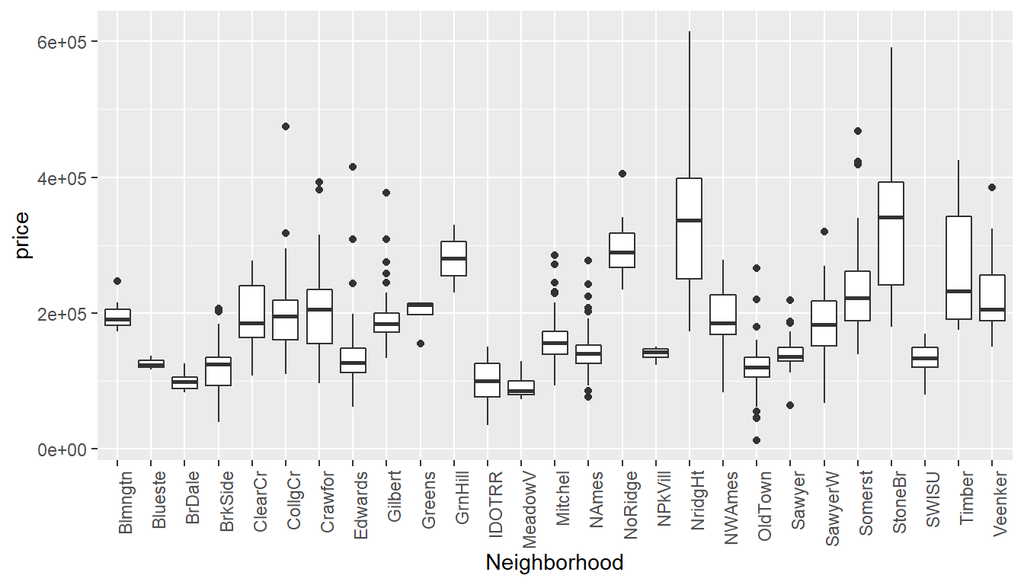

```r
# boxplot to visualize price distribution per neighborhood
ggplot(ames_train, aes(x=Neighborhood, y=price)) +
  geom_boxplot() +
  theme(axis.text.x = element_text(angle = 90, hjust = 1))
```

4. Using scatter plots or other graphical displays, which of the following variables appears to be the best single predictor of `price`?
   1. `Lot.Area`
   2. `Bedroom.AbvGr`
   3. `Overall.Qual` <-
   4. `Year.Built`

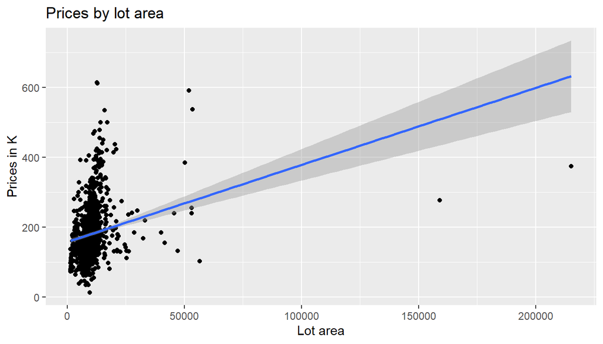

```r
# type your code for Question 4 here, and Knit
ggplot(data = ames_train, aes(x = Lot.Area, y = price/1000)) +
  geom_point() +
  stat_smooth(method = "lm") +
  labs(title="Prices by lot area", x="Lot area", y="Prices in K")
```

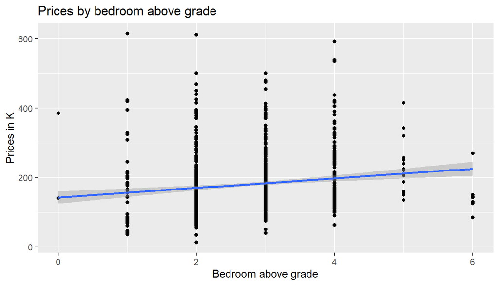

```r
ggplot(data = ames_train, aes(x = Bedroom.AbvGr, y = price/1000)) +
  geom_point() +
  stat_smooth(method = "lm") +
  labs(title="Prices by bedroom above grade", x="Bedroom above grade", y="Prices in K")
```

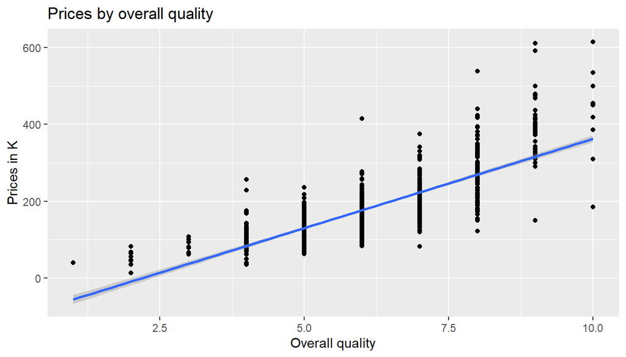

```r
ggplot(data = ames_train, aes(x = Overall.Qual, y = price/1000)) +
  geom_point() +
  stat_smooth(method = "lm") +
  labs(title="Prices by overall quality", x="Overall quality", y="Prices in K")
```

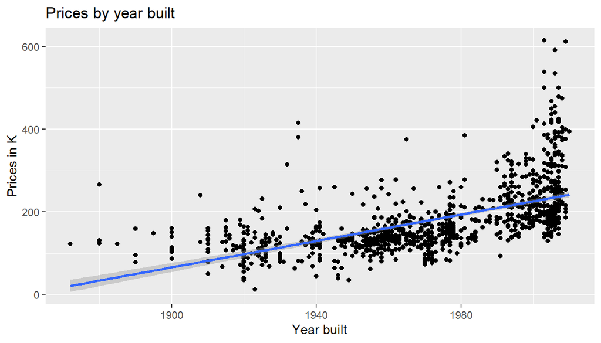

```r
ggplot(data = ames_train, aes(x = Year.Built, y = price/1000)) +
  geom_point() +
  stat_smooth(method = "lm") +
  labs(title="Prices by year built", x="Year built", y="Prices in K")
```

5. Suppose you are examining the relationship between `price` and `area`. Which of the following variable transformations makes the relationship appear to be the most linear?
   1. Do not transform either `price` or `area`
   2. Log-transform `price` but not `area`
   3. Log-transform `area` but not `price`
   4. Log-transform both `price` and `area` <-

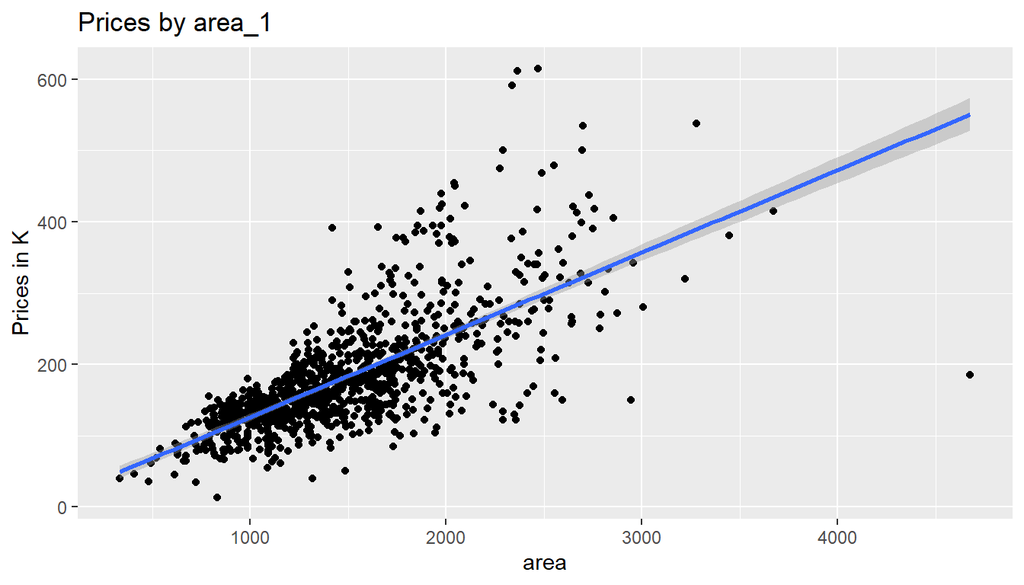

```r
# type your code for Question 5 here, and Knit
ggplot(data = ames_train, aes(x = area, y = price/1000)) +
  geom_point() +
  stat_smooth(method = "lm") +
  labs(title="Prices by area_1", x="area", y="Prices in K")
```

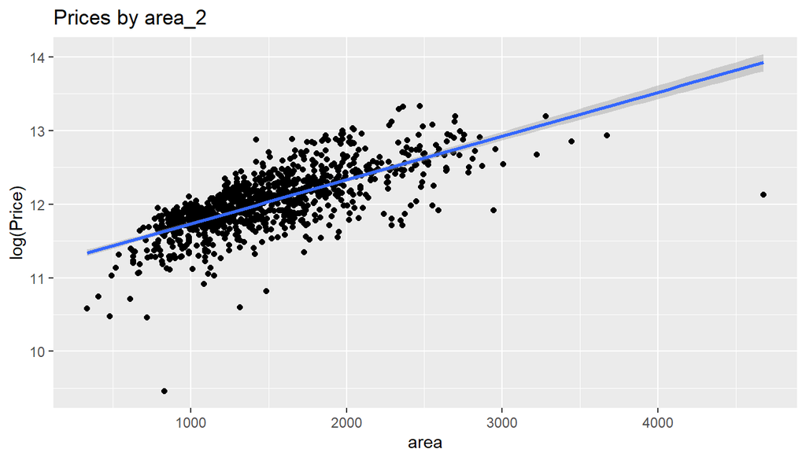

```r
ggplot(data = ames_train, aes(x = area, y = log(price))) +
  geom_point() +
  stat_smooth(method = "lm") +
  labs(title="Prices by area_2", x="area", y="log(Price)")
```

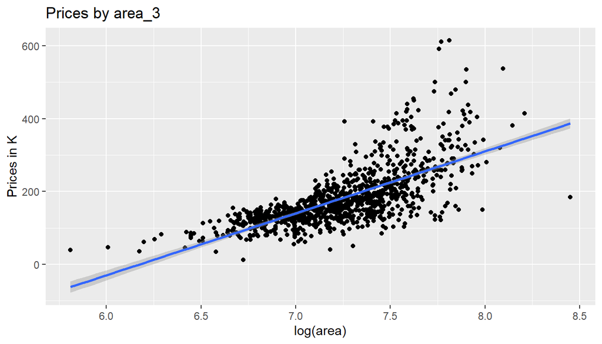

```r
ggplot(data = ames_train, aes(x = log(area), y = price/1000)) +
  geom_point() +
  stat_smooth(method = "lm") +
  labs(title="Prices by area_3", x="log(area)", y="Prices in K")
```

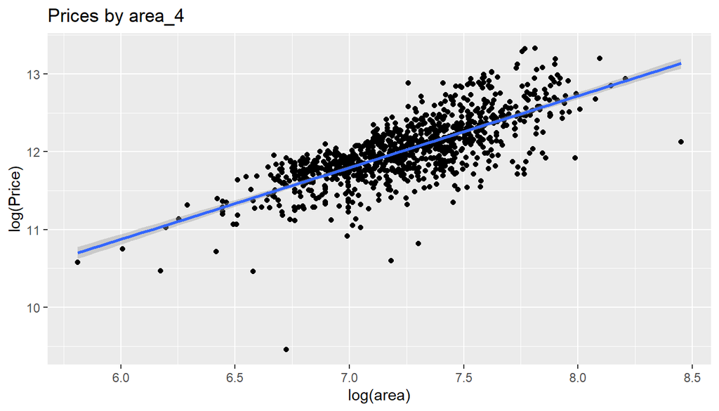

```r
ggplot(data = ames_train, aes(x = log(area), y = log(price))) +
  geom_point() +
  stat_smooth(method = "lm") +
  labs(title="Prices by area_4", x="log(area)", y="log(Price)")
```

6. Suppose that your prior for the proportion of houses that have at least one garage is Beta(9, 1). What is your posterior? Assume a beta-binomial model for this proportion.
   1. Beta(954, 46)
   2. Beta(963, 46)
   3. Beta(954, 47)
   4. Beta(963, 47) <-

```r
# type your code for Question 6 here, and Knit
table(ames_train$Garage.Cars >= 1)
```

```
##
## FALSE  TRUE
##    46   953
```

```r
# if the prior is $Beta(\alpha,\beta)$, then the posterior with $x$ successes in $n trials$ is $Beta(\alpha+x,\beta+n-x)$
```

7. Which of the following statements is true about the dataset?
   1. Over 30 percent of houses were built after the year 1999.
   2. The median housing price is greater than the mean housing price.
   3. 21 houses do not have a basement. <-
   4. 4 houses are located on gravel streets.

```r
# type your code for Question 7 here, and Knit
table(ames_train$Year.Built > 1999)
```

```
##
## FALSE  TRUE
##   728   272
```

```r
summary(ames_train$price)
```

```
##    Min. 1st Qu.  Median    Mean 3rd Qu.    Max.
##   12789  129763  159467  181190  213000  615000
```

```r
table(ames_train$Total.Bsmt.SF > 0)
```

```
##
## FALSE  TRUE
##    21   978
```

```r
table(ames_train$Street)
```

```
##
## Grvl Pave
##    3  997
```

8. Test, at the $\alpha = 0.05$ level, whether homes with a garage have larger square footage than those without a garage.
   1. With a p-value near 0.000, we reject the null hypothesis of no difference. <-
   2. With a p-value of approximately 0.032, we reject the null hypothesis of no difference.
   3. With a p-value of approximately 0.135, we fail to reject the null hypothesis of no difference.
   4. With a p-value of approximately 0.343, we fail to reject the null hypothesis of no difference.

```r
# type your code for Question 8 here, and Knit
ames_train <- ames_train %>%
  mutate(has_garage = ifelse(is.na(Garage.Type), "no", "yes"))

inference(data=ames_train, y=area, x=has_garage, type="ht", alternative = "twosided",
          method="theoretical", null=0, statistic="mean")
```

```
## Response variable: numerical
## Explanatory variable: categorical (2 levels)
## n_no = 46, y_bar_no = 1145.0435, s_no = 445.1805
## n_yes = 954, y_bar_yes = 1492.6027, s_yes = 502.5917
## H0: mu_no =  mu_yes
## HA: mu_no != mu_yes
## t = -5.1395, df = 45
## p_value = < 0.0001
```

[figure not shown]

9. For homes with square footage greater than 2000, assume that the number of bedrooms above ground follows a Poisson distribution with rate $\lambda$. Your prior on $\lambda$ follows a Gamma distribution with mean 3 and standard deviation 1. What is your posterior mean and standard deviation for the average number of bedrooms in houses with square footage greater than 2000 square feet?
   1. Mean: 3.61, SD: 0.11
   2. Mean: 3.62, SD: 0.16 <-
   3. Mean: 3.63, SD: 0.09
   4. Mean: 3.63, SD: 0.91

```r
# type your code for Question 9 here, and Knit
# lambda = 3, std = 1
# k = (lambda/std)^2, theta = std^2/lambda
# k_star = k + sum(xi)
# theta_star = theta/(n*theta + 1)
lambda <- 3
std <- 1

k <- (lambda/std)^2
theta <- std^2/lambda

c(k, theta)
```

```
## [1] 9.0000000 0.3333333
```

```r
sum_x <- ames_train %>%
  filter(area > 2000) %>%
  summarise(sum_x = sum(Bedroom.AbvGr))

n <- ames_train %>%
  filter(area > 2000) %>%
  summarise(n = n())

k_star <- k + sum_x
theta_star = theta/(n*theta+1)

c(sum_x, n, k_star, theta_star)
```

```
## $sum_x
## [1] 501
##
## $n
## [1] 138
##
## $sum_x
## [1] 510
##
## $n
## [1] 0.007092199
```

```r
lambda_star <- k_star*theta_star
std_star = theta_star*sqrt(k_star)

c(lambda_star, std_star)
```

```
## $sum_x
## [1] 3.617021
##
## $n
## [1] 0.1601644
```

10. When regressing $\log$(`price`) on $\log$(`area`), there are some outliers. Which of the following do the three most outlying points have in common?
    1. They had abnormal sale conditions.
    2. They have only two bedrooms.
    3. They have an overall quality of less than 3.
    4. They were built before 1930. <-

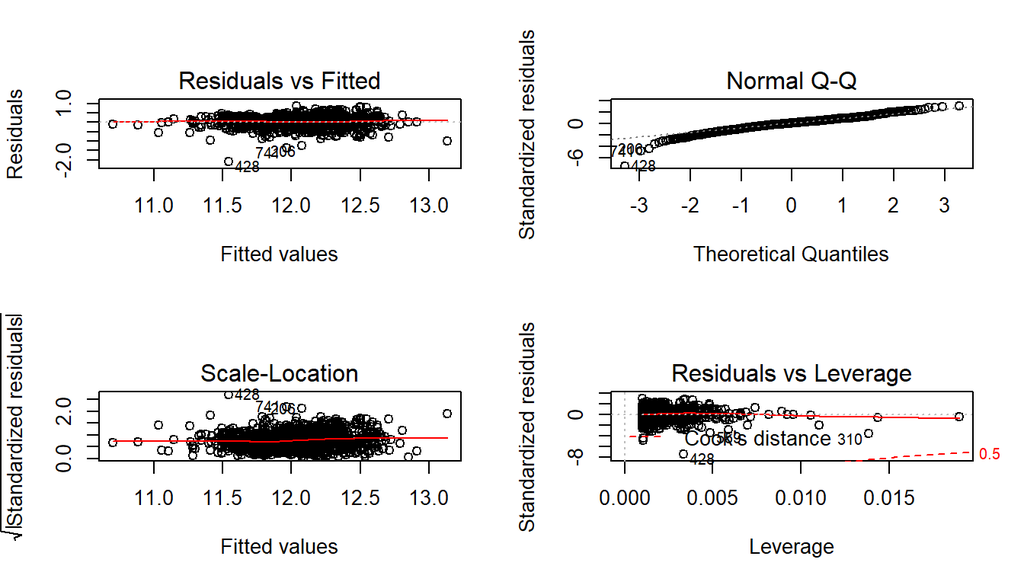

```r
# type your code for Question 10 here, and Knit
# outliers obtained from plot
lm_q10 = lm(log(price) ~ log(area), data = ames_train)
par(mfrow = c(2,2))
plot(lm_q10)
```

```r
# find outliers by setting threshold of R_squared at the (n-3)th biggest R_squared
rsquared_q10 = resid(lm_q10)**2
threshold = sort(rsquared_q10, partial=(1000-3))[997]
which(rsquared_q10 > threshold)
```

```
## 206 428 741
## 206 428 741
```

```r
ames_train$Sale.Condition[c(206, 428, 741)]
```

```
## [1] Abnorml Abnorml Normal
## Levels: Abnorml AdjLand Alloca Family Normal Partial
```

```r
ames_train$Bedroom.AbvGr[c(206, 428, 741)]
```

```
## [1] 3 2 3
```

```r
ames_train$Overall.Qual[c(206, 428, 741)]
```

```
## [1] 4 2 4
```

```r
ames_train$Year.Built[c(206, 428, 741)]
```

```
## [1] 1910 1923 1920
```

11. Which of the following are reasons to log-transform `price` if used as a dependent variable in a linear regression?
    1. `price` is right-skewed. <-
    2. `price` cannot take on negative values.
    3. `price` can only take on integer values.
    4. Both a and b.

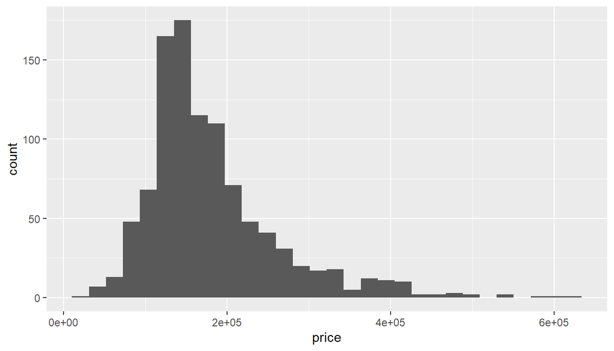

```r
# type your code for Question 11 here, and Knit
ggplot(ames_train, aes(x=price)) +
  geom_histogram()
```

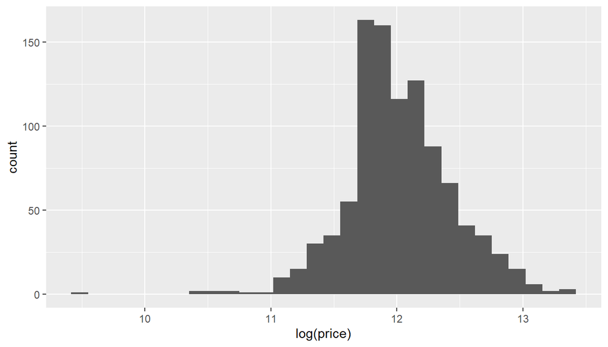

```r
ggplot(ames_train, aes(x=log(price))) +
  geom_histogram()
```

12. How many neighborhoods consist of only single-family homes? (e.g. `Bldg.Type` = `1Fam`)
    1. 0
    2. 1
    3. 2
    4. 3 <-

```r
# type your code for Question 12 here, and Knit
ames_train %>% group_by(Neighborhood) %>%
  summarise(mean_Bldg_Type = mean(Bldg.Type == "1Fam")) %>%
  filter(mean_Bldg_Type == 1)
```

```
## # A tibble: 3 x 2
##   Neighborhood mean_Bldg_Type
##   <fct>                 <dbl>
## 1 ClearCr                   1
## 2 NoRidge                   1
## 3 Timber                    1
```

13. Using color, different plotting symbols, conditioning plots, etc., does there appear to be an association between $\log$(`area`) and the number of bedrooms above ground (`Bedroom.AbvGr`)?
    1. Yes <-
    2. No

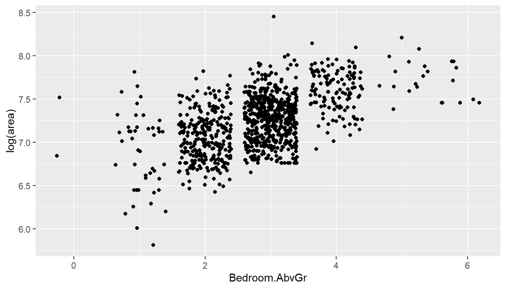

```r
# type your code for Question 13 here, and Knit
ggplot(ames_train, aes(x=Bedroom.AbvGr, y=log(area))) +
  geom_jitter()
```

14. Of the people who have unfinished basements, what is the average square footage of the unfinished basement?
    1. 590.36
    2. 595.25 <-
    3. 614.37
    4. 681.94

```r
# type your code for Question 14 here, and Knit
ames_train %>%
  filter(Bsmt.Unf.SF > 0) %>%
  summarise(mean(Bsmt.Unf.SF))
```

```
## # A tibble: 1 x 1
##   `mean(Bsmt.Unf.SF)`
##                 <dbl>
## 1                595.
```